# Data Visualization Using ggplot

## Boxplots

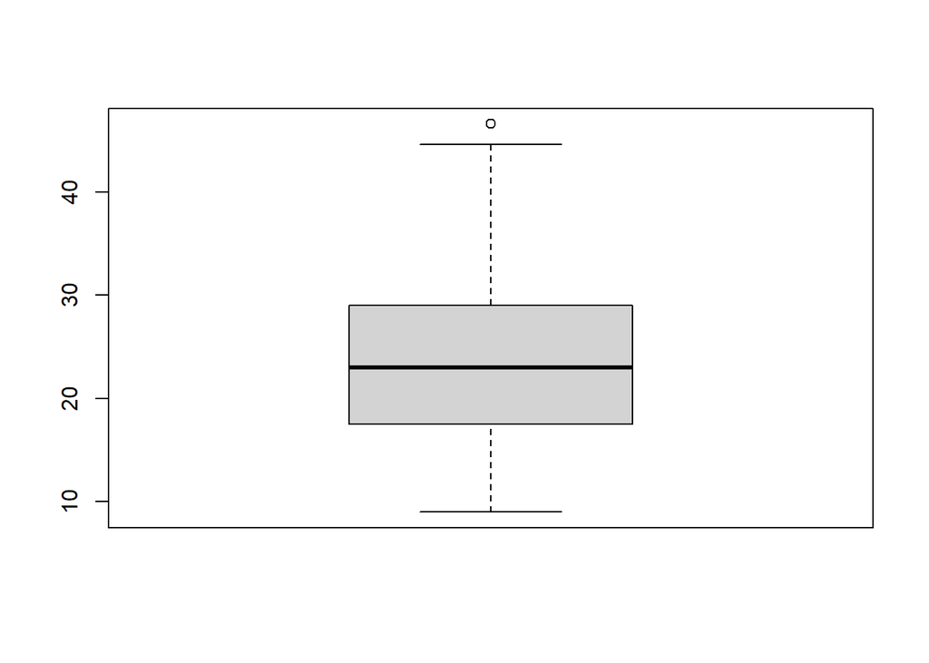

```r
boxplot(df$mpg)
```

Boxplot of mpg at each cylinder level:

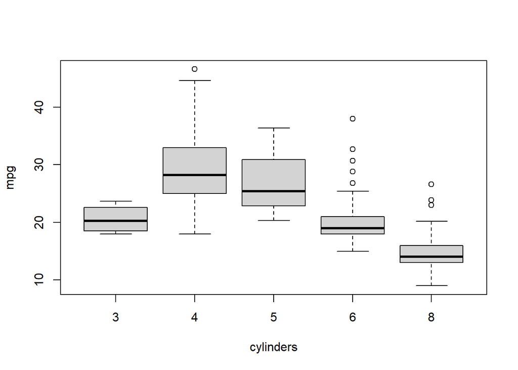

```r
boxplot(mpg ~ cylinders, data=df)
```

Let’s now create boxplots using ggplot:

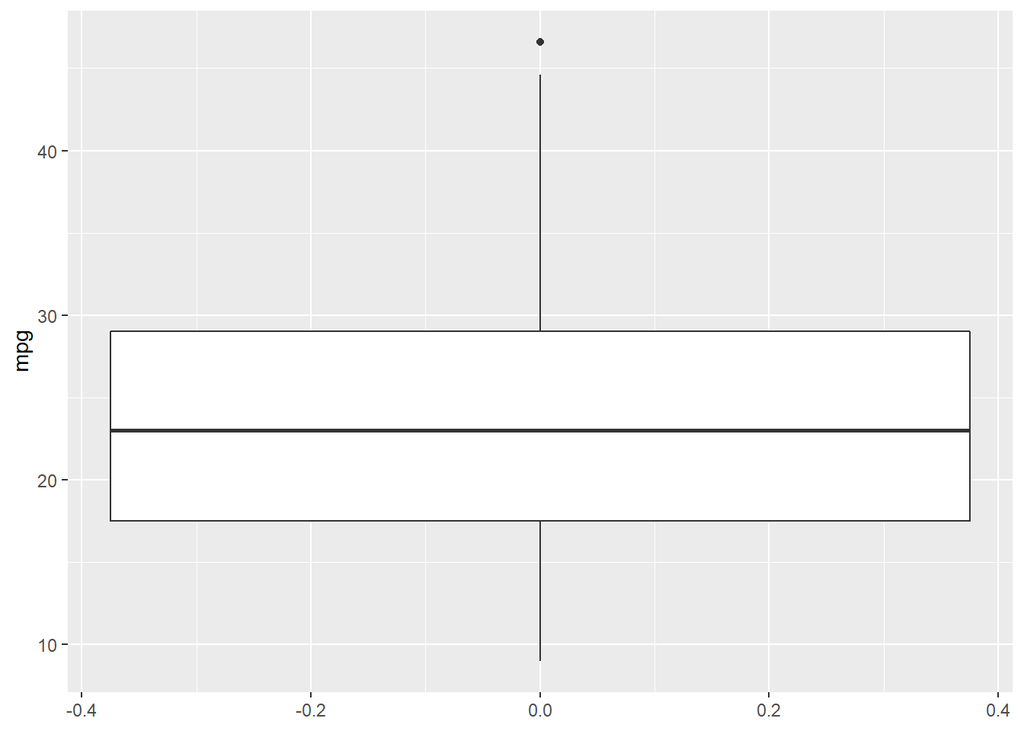

```r
ggplot(df, aes(y=mpg)) + geom_boxplot()
```

Boxplot of mpg at each cylinder level:

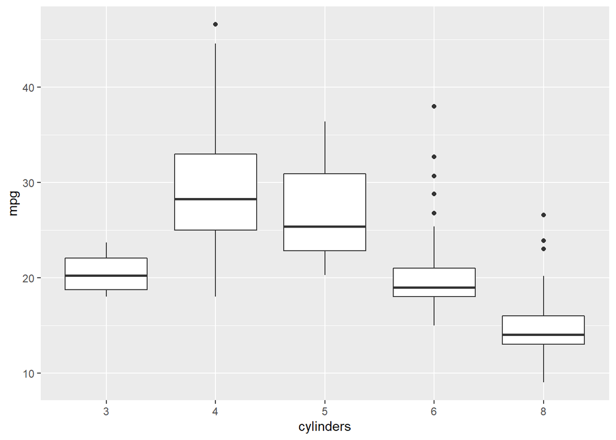

```r
ggplot(df, aes(x=cylinders, y=mpg)) + geom_boxplot()
```

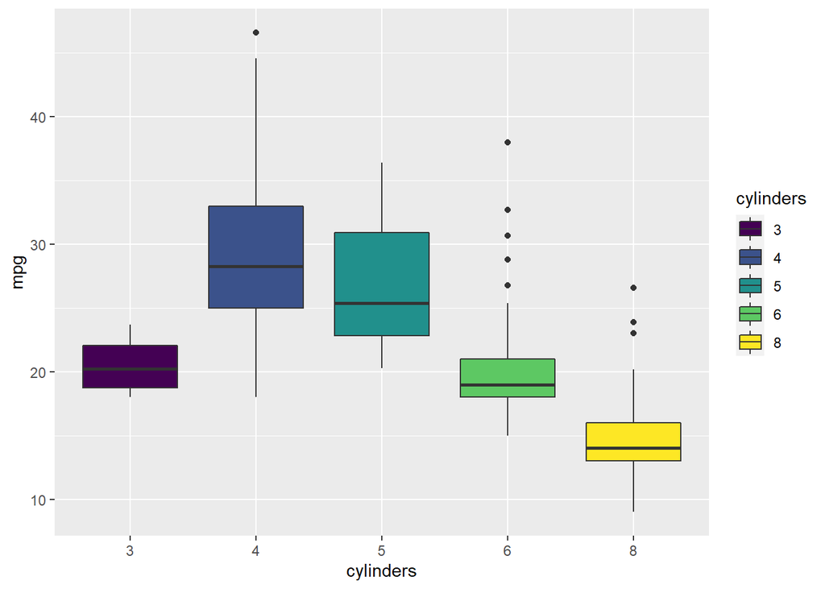

```r
ggplot(df, aes(x=cylinders, y=mpg, fill=cylinders)) + geom_boxplot()
```

## Facets

Grid divided into rows:

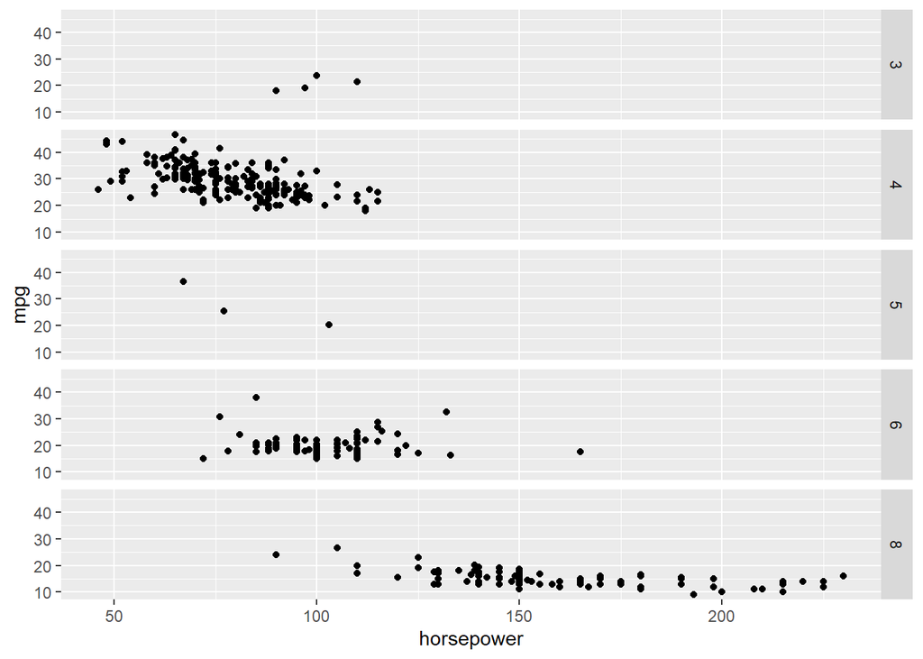

```r
ggplot(df, aes(x=horsepower, y=mpg)) + geom_point() +
    facet_grid(rows = vars(cylinders))
```

Grid divided into columns:

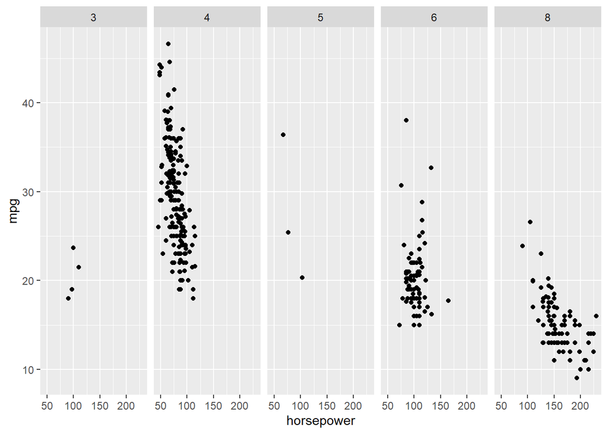

```r
ggplot(df, aes(x=horsepower, y=mpg)) + geom_point() +
    facet_grid(cols = vars(cylinders))
```

Grid divided into both columns and rows:

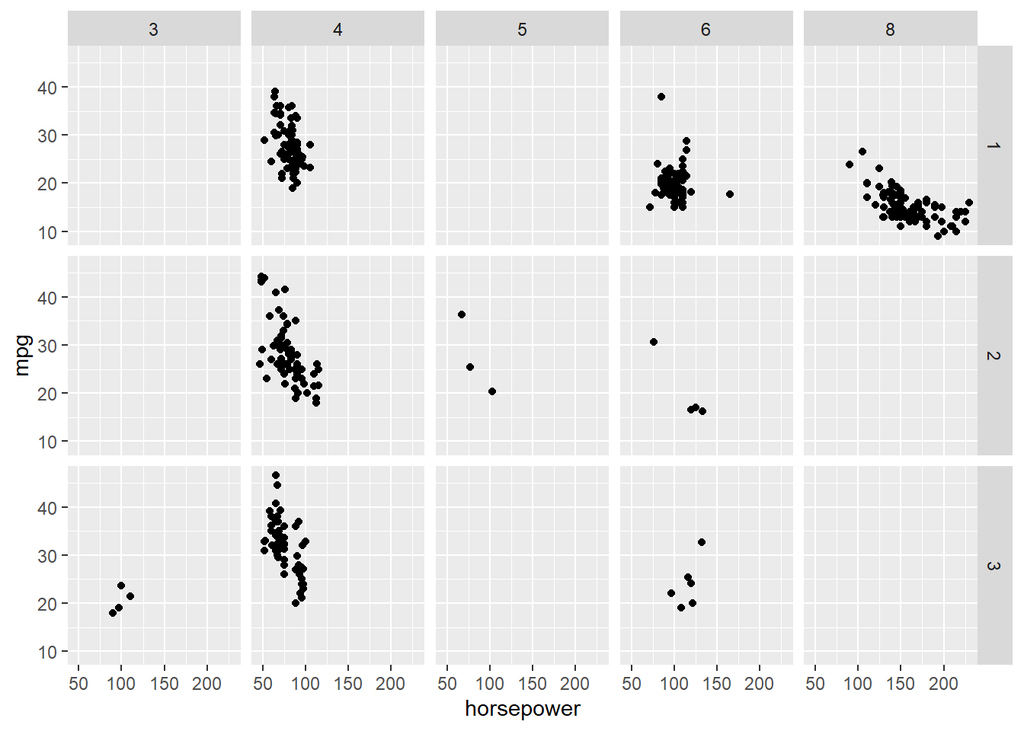

```r
ggplot(df, aes(x=horsepower, y=mpg)) + geom_point() +
    facet_grid(cols = vars(cylinders), rows=vars(origin))
```

Let’s create a binary variable for mpg. If a vehicle has less than 20 mpg it will be classified as “low”, anything above will be labelled “high”.

```r
df = df %>% mutate(mpg_label = ifelse(mpg > 20, "high", "low"))
```

Now let’s use this new variable in one of the grid sections. We will also add a 5th dimension: color. x axis, y axis, row facet, column facet, color each represent a dimension. However, be careful of adding more and more to a figure. As you add more info to a figure it becomes less readable. If there is just too much going on, it defeats the purpose of data viz which mainly is to understand data and get insights.

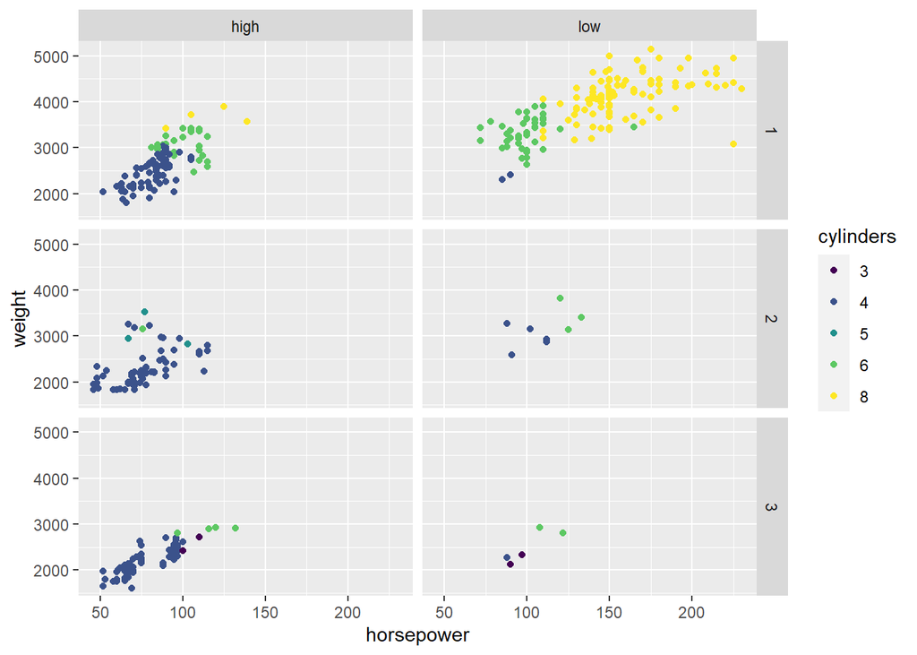

```r
ggplot(df, aes(x=horsepower, y=weight, color=cylinders)) + geom_point() +
    facet_grid(cols = vars(mpg_label), rows=vars(origin))
```

Thank you!  
Workshop organized at DSI 2022  
November 19, 2022  
Houston, TX

By: Ilyas Ustun  
Jarvis College of Computing  
DePaul University  
Chicago, IL  
iustun@depaul.edu

Twitter:  
@_ilyas_ustun_